# Risk Factor Analysis

## Outcome Variable

**Outcome Variable:** y_rate_wtkg

## Predictor Variables

**Intervention Variable:** nchldlt5

**Adjustment Set:**

unadjusted

## Stratifying Variables

The analysis was stratified on these variable(s):

- agecat
- studyid
- country

## Data Summary

| agecat | studyid | country | nchldlt5 | n_cell | n |
| --- | --- | --- | --- | --- | --- |
| 0-3 months | ki1000108-IRC | INDIA | 1 | 87 | 394 |
| 0-3 months | ki1000108-IRC | INDIA | 2+ | 307 | 394 |
| 0-3 months | ki1017093b-PROVIDE | BANGLADESH | 1 | 471 | 640 |
| 0-3 months | ki1017093b-PROVIDE | BANGLADESH | 2+ | 169 | 640 |
| 0-3 months | ki1017093c-NIH-Crypto | BANGLADESH | 1 | 516 | 725 |
| 0-3 months | ki1017093c-NIH-Crypto | BANGLADESH | 2+ | 209 | 725 |
| 0-3 months | ki1066203-TanzaniaChild2 | TANZANIA, UNITED REPUBLIC OF | 1 | 1380 | 2014 |
| 0-3 months | ki1066203-TanzaniaChild2 | TANZANIA, UNITED REPUBLIC OF | 2+ | 634 | 2014 |
| 0-3 months | kiGH5241-JiVitA-3 | BANGLADESH | 1 | 6275 | 10011 |
| 0-3 months | kiGH5241-JiVitA-3 | BANGLADESH | 2+ | 3736 | 10011 |
| 3-6 months | ki1000108-IRC | INDIA | 1 | 87 | 399 |
| 3-6 months | ki1000108-IRC | INDIA | 2+ | 312 | 399 |
| 3-6 months | ki1017093b-PROVIDE | BANGLADESH | 1 | 437 | 601 |
| 3-6 months | ki1017093b-PROVIDE | BANGLADESH | 2+ | 164 | 601 |
| 3-6 months | ki1017093c-NIH-Crypto | BANGLADESH | 1 | 498 | 702 |
| 3-6 months | ki1017093c-NIH-Crypto | BANGLADESH | 2+ | 204 | 702 |
| 3-6 months | ki1066203-TanzaniaChild2 | TANZANIA, UNITED REPUBLIC OF | 1 | 1151 | 1659 |
| 3-6 months | ki1066203-TanzaniaChild2 | TANZANIA, UNITED REPUBLIC OF | 2+ | 508 | 1659 |
| 3-6 months | kiGH5241-JiVitA-3 | BANGLADESH | 1 | 4052 | 6294 |
| 3-6 months | kiGH5241-JiVitA-3 | BANGLADESH | 2+ | 2242 | 6294 |
| 6-9 months | ki1000108-IRC | INDIA | 1 | 89 | 410 |
| 6-9 months | ki1000108-IRC | INDIA | 2+ | 321 | 410 |
| 6-9 months | ki1017093b-PROVIDE | BANGLADESH | 1 | 417 | 576 |
| 6-9 months | ki1017093b-PROVIDE | BANGLADESH | 2+ | 159 | 576 |
| 6-9 months | ki1017093c-NIH-Crypto | BANGLADESH | 1 | 491 | 693 |
| 6-9 months | ki1017093c-NIH-Crypto | BANGLADESH | 2+ | 202 | 693 |
| 6-9 months | ki1066203-TanzaniaChild2 | TANZANIA, UNITED REPUBLIC OF | 1 | 1040 | 1488 |
| 6-9 months | ki1066203-TanzaniaChild2 | TANZANIA, UNITED REPUBLIC OF | 2+ | 448 | 1488 |
| 6-9 months | ki1148112-LCNI-5 | MALAWI | 1 | 260 | 554 |
| 6-9 months | ki1148112-LCNI-5 | MALAWI | 2+ | 294 | 554 |
| 9-12 months | ki1000108-IRC | INDIA | 1 | 88 | 403 |
| 9-12 months | ki1000108-IRC | INDIA | 2+ | 315 | 403 |
| 9-12 months | ki1017093b-PROVIDE | BANGLADESH | 1 | 416 | 569 |
| 9-12 months | ki1017093b-PROVIDE | BANGLADESH | 2+ | 153 | 569 |
| 9-12 months | ki1017093c-NIH-Crypto | BANGLADESH | 1 | 482 | 683 |
| 9-12 months | ki1017093c-NIH-Crypto | BANGLADESH | 2+ | 201 | 683 |
| 9-12 months | ki1066203-TanzaniaChild2 | TANZANIA, UNITED REPUBLIC OF | 1 | 766 | 1077 |
| 9-12 months | ki1066203-TanzaniaChild2 | TANZANIA, UNITED REPUBLIC OF | 2+ | 311 | 1077 |
| 9-12 months | ki1148112-LCNI-5 | MALAWI | 1 | 179 | 380 |
| 9-12 months | ki1148112-LCNI-5 | MALAWI | 2+ | 201 | 380 |
| 12-15 months | ki1000108-IRC | INDIA | 1 | 82 | 392 |
| 12-15 months | ki1000108-IRC | INDIA | 2+ | 310 | 392 |
| 12-15 months | ki1017093b-PROVIDE | BANGLADESH | 1 | 394 | 537 |
| 12-15 months | ki1017093b-PROVIDE | BANGLADESH | 2+ | 143 | 537 |
| 12-15 months | ki1017093c-NIH-Crypto | BANGLADESH | 1 | 469 | 666 |
| 12-15 months | ki1017093c-NIH-Crypto | BANGLADESH | 2+ | 197 | 666 |
| 12-15 months | ki1066203-TanzaniaChild2 | TANZANIA, UNITED REPUBLIC OF | 1 | 570 | 786 |
| 12-15 months | ki1066203-TanzaniaChild2 | TANZANIA, UNITED REPUBLIC OF | 2+ | 216 | 786 |
| 12-15 months | ki1148112-LCNI-5 | MALAWI | 1 | 51 | 124 |
| 12-15 months | ki1148112-LCNI-5 | MALAWI | 2+ | 73 | 124 |
| 15-18 months | ki1000108-IRC | INDIA | 1 | 78 | 383 |
| 15-18 months | ki1000108-IRC | INDIA | 2+ | 305 | 383 |
| 15-18 months | ki1017093b-PROVIDE | BANGLADESH | 1 | 391 | 533 |
| 15-18 months | ki1017093b-PROVIDE | BANGLADESH | 2+ | 142 | 533 |
| 15-18 months | ki1017093c-NIH-Crypto | BANGLADESH | 1 | 426 | 605 |
| 15-18 months | ki1017093c-NIH-Crypto | BANGLADESH | 2+ | 179 | 605 |
| 15-18 months | ki1066203-TanzaniaChild2 | TANZANIA, UNITED REPUBLIC OF | 1 | 481 | 662 |
| 15-18 months | ki1066203-TanzaniaChild2 | TANZANIA, UNITED REPUBLIC OF | 2+ | 181 | 662 |
| 15-18 months | ki1148112-LCNI-5 | MALAWI | 1 | 50 | 117 |
| 15-18 months | ki1148112-LCNI-5 | MALAWI | 2+ | 67 | 117 |
| 18-21 months | ki1000108-IRC | INDIA | 1 | 82 | 380 |
| 18-21 months | ki1000108-IRC | INDIA | 2+ | 298 | 380 |
| 18-21 months | ki1017093b-PROVIDE | BANGLADESH | 1 | 394 | 542 |
| 18-21 months | ki1017093b-PROVIDE | BANGLADESH | 2+ | 148 | 542 |
| 18-21 months | ki1017093c-NIH-Crypto | BANGLADESH | 1 | 388 | 547 |
| 18-21 months | ki1017093c-NIH-Crypto | BANGLADESH | 2+ | 159 | 547 |
| 18-21 months | ki1066203-TanzaniaChild2 | TANZANIA, UNITED REPUBLIC OF | 1 | 9 | 11 |
| 18-21 months | ki1066203-TanzaniaChild2 | TANZANIA, UNITED REPUBLIC OF | 2+ | 2 | 11 |
| 18-21 months | ki1148112-LCNI-5 | MALAWI | 1 | 231 | 450 |
| 18-21 months | ki1148112-LCNI-5 | MALAWI | 2+ | 219 | 450 |
| 21-24 months | ki1000108-IRC | INDIA | 1 | 84 | 389 |
| 21-24 months | ki1000108-IRC | INDIA | 2+ | 305 | 389 |
| 21-24 months | ki1017093b-PROVIDE | BANGLADESH | 1 | 353 | 485 |
| 21-24 months | ki1017093b-PROVIDE | BANGLADESH | 2+ | 132 | 485 |
| 21-24 months | ki1017093c-NIH-Crypto | BANGLADESH | 1 | 342 | 493 |
| 21-24 months | ki1017093c-NIH-Crypto | BANGLADESH | 2+ | 151 | 493 |
| 21-24 months | ki1148112-LCNI-5 | MALAWI | 1 | 205 | 380 |
| 21-24 months | ki1148112-LCNI-5 | MALAWI | 2+ | 175 | 380 |

The following strata were considered:

- agecat: 0-3 months, studyid: ki1000108-IRC, country: INDIA
- agecat: 0-3 months, studyid: ki1017093b-PROVIDE, country: BANGLADESH
- agecat: 0-3 months, studyid: ki1017093c-NIH-Crypto, country: BANGLADESH
- agecat: 0-3 months, studyid: ki1066203-TanzaniaChild2, country: TANZANIA, UNITED REPUBLIC OF
- agecat: 0-3 months, studyid: kiGH5241-JiVitA-3, country: BANGLADESH
- agecat: 12-15 months, studyid: ki1000108-IRC, country: INDIA
- agecat: 12-15 months, studyid: ki1017093b-PROVIDE, country: BANGLADESH
- agecat: 12-15 months, studyid: ki1017093c-NIH-Crypto, country: BANGLADESH
- agecat: 12-15 months, studyid: ki1066203-TanzaniaChild2, country: TANZANIA, UNITED REPUBLIC OF
- agecat: 12-15 months, studyid: ki1148112-LCNI-5, country: MALAWI
- agecat: 15-18 months, studyid: ki1000108-IRC, country: INDIA
- agecat: 15-18 months, studyid: ki1017093b-PROVIDE, country: BANGLADESH
- agecat: 15-18 months, studyid: ki1017093c-NIH-Crypto, country: BANGLADESH
- agecat: 15-18 months, studyid: ki1066203-TanzaniaChild2, country: TANZANIA, UNITED REPUBLIC OF
- agecat: 15-18 months, studyid: ki1148112-LCNI-5, country: MALAWI
- agecat: 18-21 months, studyid: ki1000108-IRC, country: INDIA
- agecat: 18-21 months, studyid: ki1017093b-PROVIDE, country: BANGLADESH
- agecat: 18-21 months, studyid: ki1017093c-NIH-Crypto, country: BANGLADESH
- agecat: 18-21 months, studyid: ki1066203-TanzaniaChild2, country: TANZANIA, UNITED REPUBLIC OF
- agecat: 18-21 months, studyid: ki1148112-LCNI-5, country: MALAWI
- agecat: 21-24 months, studyid: ki1000108-IRC, country: INDIA
- agecat: 21-24 months, studyid: ki1017093b-PROVIDE, country: BANGLADESH
- agecat: 21-24 months, studyid: ki1017093c-NIH-Crypto, country: BANGLADESH
- agecat: 21-24 months, studyid: ki1148112-LCNI-5, country: MALAWI
- agecat: 3-6 months, studyid: ki1000108-IRC, country: INDIA
- agecat: 3-6 months, studyid: ki1017093b-PROVIDE, country: BANGLADESH
- agecat: 3-6 months, studyid: ki1017093c-NIH-Crypto, country: BANGLADESH
- agecat: 3-6 months, studyid: ki1066203-TanzaniaChild2, country: TANZANIA, UNITED REPUBLIC OF
- agecat: 3-6 months, studyid: kiGH5241-JiVitA-3, country: BANGLADESH
- agecat: 6-9 months, studyid: ki1000108-IRC, country: INDIA
- agecat: 6-9 months, studyid: ki1017093b-PROVIDE, country: BANGLADESH
- agecat: 6-9 months, studyid: ki1017093c-NIH-Crypto, country: BANGLADESH
- agecat: 6-9 months, studyid: ki1066203-TanzaniaChild2, country: TANZANIA, UNITED REPUBLIC OF
- agecat: 6-9 months, studyid: ki1148112-LCNI-5, country: MALAWI
- agecat: 9-12 months, studyid: ki1000108-IRC, country: INDIA
- agecat: 9-12 months, studyid: ki1017093b-PROVIDE, country: BANGLADESH
- agecat: 9-12 months, studyid: ki1017093c-NIH-Crypto, country: BANGLADESH
- agecat: 9-12 months, studyid: ki1066203-TanzaniaChild2, country: TANZANIA, UNITED REPUBLIC OF
- agecat: 9-12 months, studyid: ki1148112-LCNI-5, country: MALAWI

### Dropped Strata

Some strata were dropped due to rare outcomes:

- agecat: 18-21 months, studyid: ki1066203-TanzaniaChild2, country: TANZANIA, UNITED REPUBLIC OF

## Methods Detail

We’re interested in the causal parameters $E[Y_a]$ for all values of $a \in \mathcal{A}$. These parameters represent the mean outcome if, possibly contrary to fact, we intervened to set all units to have $A=a$. Under the randomization and positivity assumptions, these are identified by the statistical parameters $\psi_a=E_W[E_{Y|A,W}(Y|A=a,W)]$. In addition, we’re interested in the mean of $Y$, $E[Y]$ under no intervention (the observed mean). We will estimate these parameters by using SuperLearner to fit the relevant likelihood factors – $E_{Y|A,W}(Y|A=a,W)$ and $p(A=a|W)$, and then updating our likelihood fit using a joint TMLE.

For unadjusted analyses ($W=\{\}$), initial likelihoods were estimated using Lrnr_glm to estimate the simple $E(Y|A)$ and Lrnr_mean to estimate $p(A)$. For adjusted analyses, a small library containing Lrnr_glmnet, Lrnr_xgboost, and Lrnr_mean was used.

Having estimated these parameters, we will then use the delta method to estimate relative risks and attributable risks relative to a prespecified baseline level of $A$.

# Results Detail

## Results Plots

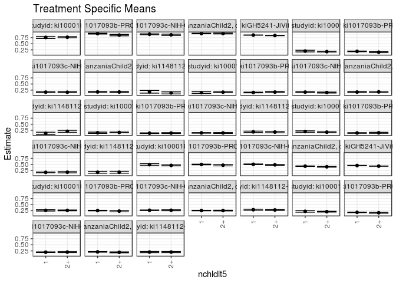

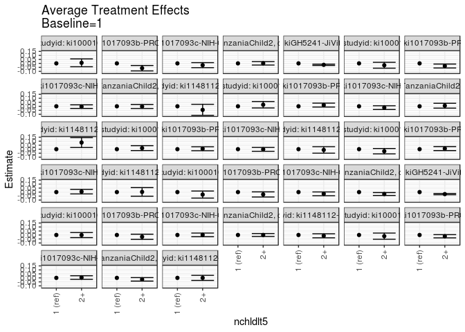

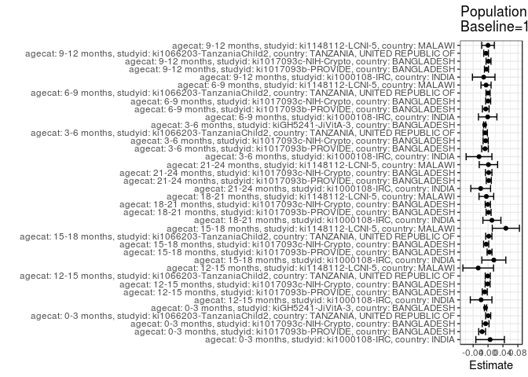

## Results Table

### Parameter: TSM

| agecat | studyid | country | intervention_level | baseline_level | estimate | ci_lower | ci_upper |
| --- | --- | --- | --- | --- | --- | --- | --- |
| 0-3 months | ki1000108-IRC | INDIA | 1 | NA | 0.7623842 | 0.7182261 | 0.8065422 |
| 0-3 months | ki1000108-IRC | INDIA | 2+ | NA | 0.7695793 | 0.7479959 | 0.7911628 |
| 0-3 months | ki1017093b-PROVIDE | BANGLADESH | 1 | NA | 0.9175253 | 0.9006810 | 0.9343696 |
| 0-3 months | ki1017093b-PROVIDE | BANGLADESH | 2+ | NA | 0.8573951 | 0.8281007 | 0.8866894 |
| 0-3 months | ki1017093c-NIH-Crypto | BANGLADESH | 1 | NA | 0.8909659 | 0.8735327 | 0.9083991 |
| 0-3 months | ki1017093c-NIH-Crypto | BANGLADESH | 2+ | NA | 0.8686124 | 0.8423922 | 0.8948327 |
| 0-3 months | ki1066203-TanzaniaChild2 | TANZANIA, UNITED REPUBLIC OF | 1 | NA | 0.9220727 | 0.9097088 | 0.9344366 |
| 0-3 months | ki1066203-TanzaniaChild2 | TANZANIA, UNITED REPUBLIC OF | 2+ | NA | 0.9230422 | 0.9051731 | 0.9409114 |
| 0-3 months | kiGH5241-JiVitA-3 | BANGLADESH | 1 | NA | 0.8573906 | 0.8521423 | 0.8626390 |
| 0-3 months | kiGH5241-JiVitA-3 | BANGLADESH | 2+ | NA | 0.8392773 | 0.8331776 | 0.8453770 |
| 3-6 months | ki1000108-IRC | INDIA | 1 | NA | 0.4902756 | 0.4505537 | 0.5299975 |
| 3-6 months | ki1000108-IRC | INDIA | 2+ | NA | 0.4593225 | 0.4398430 | 0.4788020 |
| 3-6 months | ki1017093b-PROVIDE | BANGLADESH | 1 | NA | 0.4971091 | 0.4828397 | 0.5113786 |
| 3-6 months | ki1017093b-PROVIDE | BANGLADESH | 2+ | NA | 0.4676161 | 0.4388356 | 0.4963966 |
| 3-6 months | ki1017093c-NIH-Crypto | BANGLADESH | 1 | NA | 0.5044218 | 0.4910510 | 0.5177925 |
| 3-6 months | ki1017093c-NIH-Crypto | BANGLADESH | 2+ | NA | 0.4825105 | 0.4630666 | 0.5019543 |
| 3-6 months | ki1066203-TanzaniaChild2 | TANZANIA, UNITED REPUBLIC OF | 1 | NA | 0.4270522 | 0.4164486 | 0.4376559 |
| 3-6 months | ki1066203-TanzaniaChild2 | TANZANIA, UNITED REPUBLIC OF | 2+ | NA | 0.4026731 | 0.3877219 | 0.4176243 |
| 3-6 months | kiGH5241-JiVitA-3 | BANGLADESH | 1 | NA | 0.4546017 | 0.4492384 | 0.4599650 |
| 3-6 months | kiGH5241-JiVitA-3 | BANGLADESH | 2+ | NA | 0.4293402 | 0.4228649 | 0.4358154 |
| 6-9 months | ki1000108-IRC | INDIA | 1 | NA | 0.2636122 | 0.2363993 | 0.2908250 |
| 6-9 months | ki1000108-IRC | INDIA | 2+ | NA | 0.2623590 | 0.2463341 | 0.2783838 |
| 6-9 months | ki1017093b-PROVIDE | BANGLADESH | 1 | NA | 0.2553604 | 0.2433230 | 0.2673977 |
| 6-9 months | ki1017093b-PROVIDE | BANGLADESH | 2+ | NA | 0.2329180 | 0.2029063 | 0.2629297 |
| 6-9 months | ki1017093c-NIH-Crypto | BANGLADESH | 1 | NA | 0.2671991 | 0.2545569 | 0.2798413 |
| 6-9 months | ki1017093c-NIH-Crypto | BANGLADESH | 2+ | NA | 0.2682645 | 0.2490906 | 0.2874385 |
| 6-9 months | ki1066203-TanzaniaChild2 | TANZANIA, UNITED REPUBLIC OF | 1 | NA | 0.2559082 | 0.2449260 | 0.2668904 |
| 6-9 months | ki1066203-TanzaniaChild2 | TANZANIA, UNITED REPUBLIC OF | 2+ | NA | 0.2557224 | 0.2408347 | 0.2706102 |
| 6-9 months | ki1148112-LCNI-5 | MALAWI | 1 | NA | 0.2907508 | 0.2713864 | 0.3101153 |
| 6-9 months | ki1148112-LCNI-5 | MALAWI | 2+ | NA | 0.2805666 | 0.2640657 | 0.2970675 |
| 9-12 months | ki1000108-IRC | INDIA | 1 | NA | 0.2248619 | 0.1893202 | 0.2604036 |
| 9-12 months | ki1000108-IRC | INDIA | 2+ | NA | 0.2099733 | 0.1947293 | 0.2252174 |
| 9-12 months | ki1017093b-PROVIDE | BANGLADESH | 1 | NA | 0.1817669 | 0.1706390 | 0.1928947 |
| 9-12 months | ki1017093b-PROVIDE | BANGLADESH | 2+ | NA | 0.1660161 | 0.1491282 | 0.1829039 |
| 9-12 months | ki1017093c-NIH-Crypto | BANGLADESH | 1 | NA | 0.1965114 | 0.1839700 | 0.2090528 |
| 9-12 months | ki1017093c-NIH-Crypto | BANGLADESH | 2+ | NA | 0.2010427 | 0.1825170 | 0.2195683 |
| 9-12 months | ki1066203-TanzaniaChild2 | TANZANIA, UNITED REPUBLIC OF | 1 | NA | 0.2099189 | 0.1977940 | 0.2220438 |
| 9-12 months | ki1066203-TanzaniaChild2 | TANZANIA, UNITED REPUBLIC OF | 2+ | NA | 0.1915615 | 0.1734091 | 0.2097138 |
| 9-12 months | ki1148112-LCNI-5 | MALAWI | 1 | NA | 0.2023456 | 0.1790675 | 0.2256238 |
| 9-12 months | ki1148112-LCNI-5 | MALAWI | 2+ | NA | 0.2021775 | 0.1802832 | 0.2240719 |
| 12-15 months | ki1000108-IRC | INDIA | 1 | NA | 0.2007463 | 0.1665767 | 0.2349159 |
| 12-15 months | ki1000108-IRC | INDIA | 2+ | NA | 0.1772216 | 0.1638548 | 0.1905884 |
| 12-15 months | ki1017093b-PROVIDE | BANGLADESH | 1 | NA | 0.1888552 | 0.1748298 | 0.2028806 |
| 12-15 months | ki1017093b-PROVIDE | BANGLADESH | 2+ | NA | 0.1557234 | 0.1352997 | 0.1761470 |
| 12-15 months | ki1017093c-NIH-Crypto | BANGLADESH | 1 | NA | 0.1652554 | 0.1524810 | 0.1780299 |
| 12-15 months | ki1017093c-NIH-Crypto | BANGLADESH | 2+ | NA | 0.1612149 | 0.1426493 | 0.1797805 |
| 12-15 months | ki1066203-TanzaniaChild2 | TANZANIA, UNITED REPUBLIC OF | 1 | NA | 0.1744690 | 0.1609216 | 0.1880164 |
| 12-15 months | ki1066203-TanzaniaChild2 | TANZANIA, UNITED REPUBLIC OF | 2+ | NA | 0.1717784 | 0.1512091 | 0.1923478 |
| 12-15 months | ki1148112-LCNI-5 | MALAWI | 1 | NA | 0.1794509 | 0.1242967 | 0.2346051 |
| 12-15 months | ki1148112-LCNI-5 | MALAWI | 2+ | NA | 0.1346088 | 0.0923183 | 0.1768994 |
| 15-18 months | ki1000108-IRC | INDIA | 1 | NA | 0.1449462 | 0.1070442 | 0.1828481 |
| 15-18 months | ki1000108-IRC | INDIA | 2+ | NA | 0.1644257 | 0.1504496 | 0.1784019 |
| 15-18 months | ki1017093b-PROVIDE | BANGLADESH | 1 | NA | 0.1523326 | 0.1380417 | 0.1666234 |
| 15-18 months | ki1017093b-PROVIDE | BANGLADESH | 2+ | NA | 0.1674175 | 0.1474546 | 0.1873804 |
| 15-18 months | ki1017093c-NIH-Crypto | BANGLADESH | 1 | NA | 0.1662049 | 0.1538329 | 0.1785770 |
| 15-18 months | ki1017093c-NIH-Crypto | BANGLADESH | 2+ | NA | 0.1492796 | 0.1293617 | 0.1691975 |
| 15-18 months | ki1066203-TanzaniaChild2 | TANZANIA, UNITED REPUBLIC OF | 1 | NA | 0.1681900 | 0.1509938 | 0.1853862 |
| 15-18 months | ki1066203-TanzaniaChild2 | TANZANIA, UNITED REPUBLIC OF | 2+ | NA | 0.1755857 | 0.1503662 | 0.2008051 |
| 15-18 months | ki1148112-LCNI-5 | MALAWI | 1 | NA | 0.1246751 | 0.0775896 | 0.1717605 |
| 15-18 months | ki1148112-LCNI-5 | MALAWI | 2+ | NA | 0.2081467 | 0.1674640 | 0.2488295 |
| 18-21 months | ki1000108-IRC | INDIA | 1 | NA | 0.1486303 | 0.1219299 | 0.1753307 |
| 18-21 months | ki1000108-IRC | INDIA | 2+ | NA | 0.1618268 | 0.1464417 | 0.1772119 |
| 18-21 months | ki1017093b-PROVIDE | BANGLADESH | 1 | NA | 0.1310511 | 0.1172958 | 0.1448065 |
| 18-21 months | ki1017093b-PROVIDE | BANGLADESH | 2+ | NA | 0.1363138 | 0.1159403 | 0.1566873 |
| 18-21 months | ki1017093c-NIH-Crypto | BANGLADESH | 1 | NA | 0.1432709 | 0.1306870 | 0.1558548 |
| 18-21 months | ki1017093c-NIH-Crypto | BANGLADESH | 2+ | NA | 0.1411724 | 0.1207035 | 0.1616413 |
| 18-21 months | ki1148112-LCNI-5 | MALAWI | 1 | NA | 0.1862504 | 0.1577511 | 0.2147498 |
| 18-21 months | ki1148112-LCNI-5 | MALAWI | 2+ | NA | 0.1768906 | 0.1481490 | 0.2056323 |
| 21-24 months | ki1000108-IRC | INDIA | 1 | NA | 0.1975024 | 0.1675372 | 0.2274677 |
| 21-24 months | ki1000108-IRC | INDIA | 2+ | NA | 0.1722896 | 0.1567754 | 0.1878039 |
| 21-24 months | ki1017093b-PROVIDE | BANGLADESH | 1 | NA | 0.1399697 | 0.1263777 | 0.1535617 |
| 21-24 months | ki1017093b-PROVIDE | BANGLADESH | 2+ | NA | 0.1473210 | 0.1262607 | 0.1683814 |
| 21-24 months | ki1017093c-NIH-Crypto | BANGLADESH | 1 | NA | 0.1733349 | 0.1588633 | 0.1878064 |
| 21-24 months | ki1017093c-NIH-Crypto | BANGLADESH | 2+ | NA | 0.1789348 | 0.1543100 | 0.2035595 |
| 21-24 months | ki1148112-LCNI-5 | MALAWI | 1 | NA | 0.1762591 | 0.1387163 | 0.2138019 |
| 21-24 months | ki1148112-LCNI-5 | MALAWI | 2+ | NA | 0.1783734 | 0.1401271 | 0.2166197 |

### Parameter: E(Y)

| agecat | studyid | country | intervention_level | baseline_level | estimate | ci_lower | ci_upper |
| --- | --- | --- | --- | --- | --- | --- | --- |
| 0-3 months | ki1000108-IRC | INDIA | NA | NA | 0.7679906 | 0.7485485 | 0.7874326 |
| 0-3 months | ki1017093b-PROVIDE | BANGLADESH | NA | NA | 0.9016472 | 0.8868914 | 0.9164029 |
| 0-3 months | ki1017093c-NIH-Crypto | BANGLADESH | NA | NA | 0.8845220 | 0.8699746 | 0.8990694 |
| 0-3 months | ki1066203-TanzaniaChild2 | TANZANIA, UNITED REPUBLIC OF | NA | NA | 0.9223779 | 0.9122086 | 0.9325472 |
| 0-3 months | kiGH5241-JiVitA-3 | BANGLADESH | NA | NA | 0.8506309 | 0.8465840 | 0.8546779 |
| 3-6 months | ki1000108-IRC | INDIA | NA | NA | 0.4660717 | 0.4485044 | 0.4836390 |
| 3-6 months | ki1017093b-PROVIDE | BANGLADESH | NA | NA | 0.4890611 | 0.4760060 | 0.5021163 |
| 3-6 months | ki1017093c-NIH-Crypto | BANGLADESH | NA | NA | 0.4980544 | 0.4869892 | 0.5091196 |
| 3-6 months | ki1066203-TanzaniaChild2 | TANZANIA, UNITED REPUBLIC OF | NA | NA | 0.4195871 | 0.4109053 | 0.4282689 |
| 3-6 months | kiGH5241-JiVitA-3 | BANGLADESH | NA | NA | 0.4456032 | 0.4413188 | 0.4498877 |
| 6-9 months | ki1000108-IRC | INDIA | NA | NA | 0.2626310 | 0.2487635 | 0.2764985 |
| 6-9 months | ki1017093b-PROVIDE | BANGLADESH | NA | NA | 0.2491653 | 0.2371134 | 0.2612172 |
| 6-9 months | ki1017093c-NIH-Crypto | BANGLADESH | NA | NA | 0.2675097 | 0.2569518 | 0.2780676 |
| 6-9 months | ki1066203-TanzaniaChild2 | TANZANIA, UNITED REPUBLIC OF | NA | NA | 0.2558522 | 0.2469636 | 0.2647409 |
| 6-9 months | ki1148112-LCNI-5 | MALAWI | NA | NA | 0.2853462 | 0.2727187 | 0.2979736 |
| 9-12 months | ki1000108-IRC | INDIA | NA | NA | 0.2132244 | 0.1989917 | 0.2274571 |
| 9-12 months | ki1017093b-PROVIDE | BANGLADESH | NA | NA | 0.1775316 | 0.1681968 | 0.1868664 |
| 9-12 months | ki1017093c-NIH-Crypto | BANGLADESH | NA | NA | 0.1978449 | 0.1874487 | 0.2082411 |
| 9-12 months | ki1066203-TanzaniaChild2 | TANZANIA, UNITED REPUBLIC OF | NA | NA | 0.2046179 | 0.1945139 | 0.2147219 |
| 9-12 months | ki1148112-LCNI-5 | MALAWI | NA | NA | 0.2022567 | 0.1863082 | 0.2182053 |
| 12-15 months | ki1000108-IRC | INDIA | NA | NA | 0.1821426 | 0.1693469 | 0.1949383 |
| 12-15 months | ki1017093b-PROVIDE | BANGLADESH | NA | NA | 0.1800324 | 0.1683272 | 0.1917375 |
| 12-15 months | ki1017093c-NIH-Crypto | BANGLADESH | NA | NA | 0.1640603 | 0.1535198 | 0.1746008 |
| 12-15 months | ki1066203-TanzaniaChild2 | TANZANIA, UNITED REPUBLIC OF | NA | NA | 0.1737296 | 0.1623947 | 0.1850645 |
| 12-15 months | ki1148112-LCNI-5 | MALAWI | NA | NA | 0.1530519 | 0.1191456 | 0.1869583 |
| 15-18 months | ki1000108-IRC | INDIA | NA | NA | 0.1604586 | 0.1468913 | 0.1740260 |
| 15-18 months | ki1017093b-PROVIDE | BANGLADESH | NA | NA | 0.1563514 | 0.1445823 | 0.1681205 |
| 15-18 months | ki1017093c-NIH-Crypto | BANGLADESH | NA | NA | 0.1611973 | 0.1506617 | 0.1717329 |
| 15-18 months | ki1066203-TanzaniaChild2 | TANZANIA, UNITED REPUBLIC OF | NA | NA | 0.1702121 | 0.1559390 | 0.1844852 |
| 15-18 months | ki1148112-LCNI-5 | MALAWI | NA | NA | 0.1724751 | 0.1407874 | 0.2041628 |
| 18-21 months | ki1000108-IRC | INDIA | NA | NA | 0.1589791 | 0.1455977 | 0.1723606 |
| 18-21 months | ki1017093b-PROVIDE | BANGLADESH | NA | NA | 0.1324882 | 0.1210438 | 0.1439326 |
| 18-21 months | ki1017093c-NIH-Crypto | BANGLADESH | NA | NA | 0.1426609 | 0.1319333 | 0.1533885 |
| 18-21 months | ki1148112-LCNI-5 | MALAWI | NA | NA | 0.1816953 | 0.1614502 | 0.2019405 |
| 21-24 months | ki1000108-IRC | INDIA | NA | NA | 0.1777340 | 0.1639174 | 0.1915507 |
| 21-24 months | ki1017093b-PROVIDE | BANGLADESH | NA | NA | 0.1419705 | 0.1305335 | 0.1534075 |
| 21-24 months | ki1017093c-NIH-Crypto | BANGLADESH | NA | NA | 0.1750500 | 0.1624914 | 0.1876087 |
| 21-24 months | ki1148112-LCNI-5 | MALAWI | NA | NA | 0.1772328 | 0.1503917 | 0.2040738 |

### Parameter: ATE

| agecat | studyid | country | intervention_level | baseline_level | estimate | ci_lower | ci_upper |
| --- | --- | --- | --- | --- | --- | --- | --- |
| 0-3 months | ki1000108-IRC | INDIA | 1 | 1 | 0.0000000 | 0.0000000 | 0.0000000 |
| 0-3 months | ki1000108-IRC | INDIA | 2+ | 1 | 0.0071952 | -0.0419554 | 0.0563457 |
| 0-3 months | ki1017093b-PROVIDE | BANGLADESH | 1 | 1 | 0.0000000 | 0.0000000 | 0.0000000 |
| 0-3 months | ki1017093b-PROVIDE | BANGLADESH | 2+ | 1 | -0.0601303 | -0.0939221 | -0.0263384 |
| 0-3 months | ki1017093c-NIH-Crypto | BANGLADESH | 1 | 1 | 0.0000000 | 0.0000000 | 0.0000000 |
| 0-3 months | ki1017093c-NIH-Crypto | BANGLADESH | 2+ | 1 | -0.0223535 | -0.0538403 | 0.0091333 |
| 0-3 months | ki1066203-TanzaniaChild2 | TANZANIA, UNITED REPUBLIC OF | 1 | 1 | 0.0000000 | 0.0000000 | 0.0000000 |
| 0-3 months | ki1066203-TanzaniaChild2 | TANZANIA, UNITED REPUBLIC OF | 2+ | 1 | 0.0009696 | -0.0207600 | 0.0226991 |
| 0-3 months | kiGH5241-JiVitA-3 | BANGLADESH | 1 | 1 | 0.0000000 | 0.0000000 | 0.0000000 |
| 0-3 months | kiGH5241-JiVitA-3 | BANGLADESH | 2+ | 1 | -0.0181133 | -0.0261175 | -0.0101092 |
| 3-6 months | ki1000108-IRC | INDIA | 1 | 1 | 0.0000000 | 0.0000000 | 0.0000000 |
| 3-6 months | ki1000108-IRC | INDIA | 2+ | 1 | -0.0309531 | -0.0751942 | 0.0132880 |
| 3-6 months | ki1017093b-PROVIDE | BANGLADESH | 1 | 1 | 0.0000000 | 0.0000000 | 0.0000000 |
| 3-6 months | ki1017093b-PROVIDE | BANGLADESH | 2+ | 1 | -0.0294930 | -0.0616168 | 0.0026307 |
| 3-6 months | ki1017093c-NIH-Crypto | BANGLADESH | 1 | 1 | 0.0000000 | 0.0000000 | 0.0000000 |
| 3-6 months | ki1017093c-NIH-Crypto | BANGLADESH | 2+ | 1 | -0.0219113 | -0.0455088 | 0.0016862 |
| 3-6 months | ki1066203-TanzaniaChild2 | TANZANIA, UNITED REPUBLIC OF | 1 | 1 | 0.0000000 | 0.0000000 | 0.0000000 |
| 3-6 months | ki1066203-TanzaniaChild2 | TANZANIA, UNITED REPUBLIC OF | 2+ | 1 | -0.0243792 | -0.0427088 | -0.0060495 |
| 3-6 months | kiGH5241-JiVitA-3 | BANGLADESH | 1 | 1 | 0.0000000 | 0.0000000 | 0.0000000 |
| 3-6 months | kiGH5241-JiVitA-3 | BANGLADESH | 2+ | 1 | -0.0252616 | -0.0334447 | -0.0170784 |
| 6-9 months | ki1000108-IRC | INDIA | 1 | 1 | 0.0000000 | 0.0000000 | 0.0000000 |
| 6-9 months | ki1000108-IRC | INDIA | 2+ | 1 | -0.0012532 | -0.0328338 | 0.0303274 |
| 6-9 months | ki1017093b-PROVIDE | BANGLADESH | 1 | 1 | 0.0000000 | 0.0000000 | 0.0000000 |
| 6-9 months | ki1017093b-PROVIDE | BANGLADESH | 2+ | 1 | -0.0224424 | -0.0547781 | 0.0098933 |
| 6-9 months | ki1017093c-NIH-Crypto | BANGLADESH | 1 | 1 | 0.0000000 | 0.0000000 | 0.0000000 |
| 6-9 months | ki1017093c-NIH-Crypto | BANGLADESH | 2+ | 1 | 0.0010654 | -0.0219012 | 0.0240320 |
| 6-9 months | ki1066203-TanzaniaChild2 | TANZANIA, UNITED REPUBLIC OF | 1 | 1 | 0.0000000 | 0.0000000 | 0.0000000 |
| 6-9 months | ki1066203-TanzaniaChild2 | TANZANIA, UNITED REPUBLIC OF | 2+ | 1 | -0.0001857 | -0.0186858 | 0.0183144 |
| 6-9 months | ki1148112-LCNI-5 | MALAWI | 1 | 1 | 0.0000000 | 0.0000000 | 0.0000000 |
| 6-9 months | ki1148112-LCNI-5 | MALAWI | 2+ | 1 | -0.0101843 | -0.0356256 | 0.0152571 |
| 9-12 months | ki1000108-IRC | INDIA | 1 | 1 | 0.0000000 | 0.0000000 | 0.0000000 |
| 9-12 months | ki1000108-IRC | INDIA | 2+ | 1 | -0.0148886 | -0.0535615 | 0.0237844 |
| 9-12 months | ki1017093b-PROVIDE | BANGLADESH | 1 | 1 | 0.0000000 | 0.0000000 | 0.0000000 |
| 9-12 months | ki1017093b-PROVIDE | BANGLADESH | 2+ | 1 | -0.0157508 | -0.0359752 | 0.0044736 |
| 9-12 months | ki1017093c-NIH-Crypto | BANGLADESH | 1 | 1 | 0.0000000 | 0.0000000 | 0.0000000 |
| 9-12 months | ki1017093c-NIH-Crypto | BANGLADESH | 2+ | 1 | 0.0045313 | -0.0178402 | 0.0269029 |
| 9-12 months | ki1066203-TanzaniaChild2 | TANZANIA, UNITED REPUBLIC OF | 1 | 1 | 0.0000000 | 0.0000000 | 0.0000000 |
| 9-12 months | ki1066203-TanzaniaChild2 | TANZANIA, UNITED REPUBLIC OF | 2+ | 1 | -0.0183574 | -0.0401868 | 0.0034719 |
| 9-12 months | ki1148112-LCNI-5 | MALAWI | 1 | 1 | 0.0000000 | 0.0000000 | 0.0000000 |
| 9-12 months | ki1148112-LCNI-5 | MALAWI | 2+ | 1 | -0.0001681 | -0.0321249 | 0.0317887 |
| 12-15 months | ki1000108-IRC | INDIA | 1 | 1 | 0.0000000 | 0.0000000 | 0.0000000 |
| 12-15 months | ki1000108-IRC | INDIA | 2+ | 1 | -0.0235247 | -0.0602157 | 0.0131664 |
| 12-15 months | ki1017093b-PROVIDE | BANGLADESH | 1 | 1 | 0.0000000 | 0.0000000 | 0.0000000 |
| 12-15 months | ki1017093b-PROVIDE | BANGLADESH | 2+ | 1 | -0.0331318 | -0.0579075 | -0.0083561 |
| 12-15 months | ki1017093c-NIH-Crypto | BANGLADESH | 1 | 1 | 0.0000000 | 0.0000000 | 0.0000000 |
| 12-15 months | ki1017093c-NIH-Crypto | BANGLADESH | 2+ | 1 | -0.0040406 | -0.0265765 | 0.0184954 |
| 12-15 months | ki1066203-TanzaniaChild2 | TANZANIA, UNITED REPUBLIC OF | 1 | 1 | 0.0000000 | 0.0000000 | 0.0000000 |
| 12-15 months | ki1066203-TanzaniaChild2 | TANZANIA, UNITED REPUBLIC OF | 2+ | 1 | -0.0026905 | -0.0273204 | 0.0219393 |
| 12-15 months | ki1148112-LCNI-5 | MALAWI | 1 | 1 | 0.0000000 | 0.0000000 | 0.0000000 |
| 12-15 months | ki1148112-LCNI-5 | MALAWI | 2+ | 1 | -0.0448420 | -0.1143436 | 0.0246596 |
| 15-18 months | ki1000108-IRC | INDIA | 1 | 1 | 0.0000000 | 0.0000000 | 0.0000000 |
| 15-18 months | ki1000108-IRC | INDIA | 2+ | 1 | 0.0194796 | -0.0209170 | 0.0598762 |
| 15-18 months | ki1017093b-PROVIDE | BANGLADESH | 1 | 1 | 0.0000000 | 0.0000000 | 0.0000000 |
| 15-18 months | ki1017093b-PROVIDE | BANGLADESH | 2+ | 1 | 0.0150849 | -0.0094660 | 0.0396358 |
| 15-18 months | ki1017093c-NIH-Crypto | BANGLADESH | 1 | 1 | 0.0000000 | 0.0000000 | 0.0000000 |
| 15-18 months | ki1017093c-NIH-Crypto | BANGLADESH | 2+ | 1 | -0.0169253 | -0.0403729 | 0.0065222 |
| 15-18 months | ki1066203-TanzaniaChild2 | TANZANIA, UNITED REPUBLIC OF | 1 | 1 | 0.0000000 | 0.0000000 | 0.0000000 |
| 15-18 months | ki1066203-TanzaniaChild2 | TANZANIA, UNITED REPUBLIC OF | 2+ | 1 | 0.0073957 | -0.0231286 | 0.0379199 |
| 15-18 months | ki1148112-LCNI-5 | MALAWI | 1 | 1 | 0.0000000 | 0.0000000 | 0.0000000 |
| 15-18 months | ki1148112-LCNI-5 | MALAWI | 2+ | 1 | 0.0834717 | 0.0212453 | 0.1456981 |
| 18-21 months | ki1000108-IRC | INDIA | 1 | 1 | 0.0000000 | 0.0000000 | 0.0000000 |
| 18-21 months | ki1000108-IRC | INDIA | 2+ | 1 | 0.0131965 | -0.0176193 | 0.0440123 |
| 18-21 months | ki1017093b-PROVIDE | BANGLADESH | 1 | 1 | 0.0000000 | 0.0000000 | 0.0000000 |
| 18-21 months | ki1017093b-PROVIDE | BANGLADESH | 2+ | 1 | 0.0052627 | -0.0193196 | 0.0298449 |
| 18-21 months | ki1017093c-NIH-Crypto | BANGLADESH | 1 | 1 | 0.0000000 | 0.0000000 | 0.0000000 |
| 18-21 months | ki1017093c-NIH-Crypto | BANGLADESH | 2+ | 1 | -0.0020985 | -0.0261262 | 0.0219292 |
| 18-21 months | ki1148112-LCNI-5 | MALAWI | 1 | 1 | 0.0000000 | 0.0000000 | 0.0000000 |
| 18-21 months | ki1148112-LCNI-5 | MALAWI | 2+ | 1 | -0.0093598 | -0.0498356 | 0.0311161 |
| 21-24 months | ki1000108-IRC | INDIA | 1 | 1 | 0.0000000 | 0.0000000 | 0.0000000 |
| 21-24 months | ki1000108-IRC | INDIA | 2+ | 1 | -0.0252128 | -0.0589561 | 0.0085305 |
| 21-24 months | ki1017093b-PROVIDE | BANGLADESH | 1 | 1 | 0.0000000 | 0.0000000 | 0.0000000 |
| 21-24 months | ki1017093b-PROVIDE | BANGLADESH | 2+ | 1 | 0.0073513 | -0.0177142 | 0.0324169 |
| 21-24 months | ki1017093c-NIH-Crypto | BANGLADESH | 1 | 1 | 0.0000000 | 0.0000000 | 0.0000000 |
| 21-24 months | ki1017093c-NIH-Crypto | BANGLADESH | 2+ | 1 | 0.0055999 | -0.0229624 | 0.0341622 |
| 21-24 months | ki1148112-LCNI-5 | MALAWI | 1 | 1 | 0.0000000 | 0.0000000 | 0.0000000 |
| 21-24 months | ki1148112-LCNI-5 | MALAWI | 2+ | 1 | 0.0021143 | -0.0514790 | 0.0557076 |

### Parameter: PAR

| agecat | studyid | country | intervention_level | baseline_level | estimate | ci_lower | ci_upper |
| --- | --- | --- | --- | --- | --- | --- | --- |
| 0-3 months | ki1000108-IRC | INDIA | 1 | NA | 0.0056064 | -0.0326923 | 0.0439051 |
| 0-3 months | ki1017093b-PROVIDE | BANGLADESH | 1 | NA | -0.0158781 | -0.0250349 | -0.0067214 |
| 0-3 months | ki1017093c-NIH-Crypto | BANGLADESH | 1 | NA | -0.0064440 | -0.0155508 | 0.0026628 |
| 0-3 months | ki1066203-TanzaniaChild2 | TANZANIA, UNITED REPUBLIC OF | 1 | NA | 0.0003052 | -0.0065352 | 0.0071456 |
| 0-3 months | kiGH5241-JiVitA-3 | BANGLADESH | 1 | NA | -0.0067597 | -0.0097576 | -0.0037619 |
| 3-6 months | ki1000108-IRC | INDIA | 1 | NA | -0.0242039 | -0.0588213 | 0.0104134 |
| 3-6 months | ki1017093b-PROVIDE | BANGLADESH | 1 | NA | -0.0080480 | -0.0168767 | 0.0007807 |
| 3-6 months | ki1017093c-NIH-Crypto | BANGLADESH | 1 | NA | -0.0063674 | -0.0132642 | 0.0005294 |
| 3-6 months | ki1066203-TanzaniaChild2 | TANZANIA, UNITED REPUBLIC OF | 1 | NA | -0.0074651 | -0.0131038 | -0.0018264 |
| 3-6 months | kiGH5241-JiVitA-3 | BANGLADESH | 1 | NA | -0.0089985 | -0.0119159 | -0.0060811 |
| 6-9 months | ki1000108-IRC | INDIA | 1 | NA | -0.0009812 | -0.0257065 | 0.0237442 |
| 6-9 months | ki1017093b-PROVIDE | BANGLADESH | 1 | NA | -0.0061950 | -0.0151586 | 0.0027686 |
| 6-9 months | ki1017093c-NIH-Crypto | BANGLADESH | 1 | NA | 0.0003106 | -0.0063840 | 0.0070051 |
| 6-9 months | ki1066203-TanzaniaChild2 | TANZANIA, UNITED REPUBLIC OF | 1 | NA | -0.0000559 | -0.0056258 | 0.0055140 |
| 6-9 months | ki1148112-LCNI-5 | MALAWI | 1 | NA | -0.0054046 | -0.0189127 | 0.0081034 |
| 9-12 months | ki1000108-IRC | INDIA | 1 | NA | -0.0116375 | -0.0418717 | 0.0185967 |
| 9-12 months | ki1017093b-PROVIDE | BANGLADESH | 1 | NA | -0.0042353 | -0.0097037 | 0.0012332 |
| 9-12 months | ki1017093c-NIH-Crypto | BANGLADESH | 1 | NA | 0.0013335 | -0.0052520 | 0.0079191 |
| 9-12 months | ki1066203-TanzaniaChild2 | TANZANIA, UNITED REPUBLIC OF | 1 | NA | -0.0053010 | -0.0116241 | 0.0010221 |
| 9-12 months | ki1148112-LCNI-5 | MALAWI | 1 | NA | -0.0000889 | -0.0169924 | 0.0168146 |
| 12-15 months | ki1000108-IRC | INDIA | 1 | NA | -0.0186037 | -0.0476350 | 0.0104277 |
| 12-15 months | ki1017093b-PROVIDE | BANGLADESH | 1 | NA | -0.0088228 | -0.0155359 | -0.0021097 |
| 12-15 months | ki1017093c-NIH-Crypto | BANGLADESH | 1 | NA | -0.0011952 | -0.0078627 | 0.0054723 |
| 12-15 months | ki1066203-TanzaniaChild2 | TANZANIA, UNITED REPUBLIC OF | 1 | NA | -0.0007394 | -0.0075084 | 0.0060296 |
| 12-15 months | ki1148112-LCNI-5 | MALAWI | 1 | NA | -0.0263989 | -0.0675006 | 0.0147027 |
| 15-18 months | ki1000108-IRC | INDIA | 1 | NA | 0.0155125 | -0.0166668 | 0.0476917 |
| 15-18 months | ki1017093b-PROVIDE | BANGLADESH | 1 | NA | 0.0040189 | -0.0025464 | 0.0105841 |
| 15-18 months | ki1017093c-NIH-Crypto | BANGLADESH | 1 | NA | -0.0050077 | -0.0119723 | 0.0019570 |
| 15-18 months | ki1066203-TanzaniaChild2 | TANZANIA, UNITED REPUBLIC OF | 1 | NA | 0.0020221 | -0.0063275 | 0.0103716 |
| 15-18 months | ki1148112-LCNI-5 | MALAWI | 1 | NA | 0.0478000 | 0.0113824 | 0.0842177 |
| 18-21 months | ki1000108-IRC | INDIA | 1 | NA | 0.0103488 | -0.0138234 | 0.0345211 |
| 18-21 months | ki1017093b-PROVIDE | BANGLADESH | 1 | NA | 0.0014370 | -0.0052784 | 0.0081524 |
| 18-21 months | ki1017093c-NIH-Crypto | BANGLADESH | 1 | NA | -0.0006100 | -0.0075947 | 0.0063748 |
| 18-21 months | ki1148112-LCNI-5 | MALAWI | 1 | NA | -0.0045551 | -0.0242581 | 0.0151479 |
| 21-24 months | ki1000108-IRC | INDIA | 1 | NA | -0.0197684 | -0.0462453 | 0.0067086 |
| 21-24 months | ki1017093b-PROVIDE | BANGLADESH | 1 | NA | 0.0020008 | -0.0048274 | 0.0088290 |
| 21-24 months | ki1017093c-NIH-Crypto | BANGLADESH | 1 | NA | 0.0017152 | -0.0070361 | 0.0104664 |
| 21-24 months | ki1148112-LCNI-5 | MALAWI | 1 | NA | 0.0009737 | -0.0237077 | 0.0256551 |